# Large scale biodiversity patterns

Showing some neat features of R!

Author

Affiliation

[Jesús N. Pinto-Ledezma](https://jesusnpl.github.io)

[Ecology, Evolution & Behavior, University of Minnesota Biodiversity Science - EBB 3534-5534](https://github.com/jesusNPL/BiodiversityScience)

Published

February 12, 2026

**Note**

Since the eighteenth century, broad-scale patterns of diversity called the attention of naturalists. Recognizing that tropical regions have higher species richness relative to temperate areas, Alexander von Humboldt was the first one to propose it to emerge from climatic differences (Hawkins, 2001). This ubiquitous pattern has since then been known as the Latitudinal Diversity Gradient (LDG) and, although the global distribution of biodiversity is indeed far more complex than a simple unidirectional gradient (Hawkins & Felizola Diniz-Filho, 2004), the difference in species richness between temperate and tropical regions tends to capture the most evident facet of the distribution of life on Earth: its geographic heterogeneity.

Early explanations for the LDG in the 1950s and 1960s followed von Humboldt’s tradition and focused on the strong correlations observed between diversity (i.e., species richness) and components of current environmental variation—especially combinations of temperature and precipitation (Brown, 2014; Hawkins et al., 2003; O’Brien, 2006; Pianka, 1966; Simpson, 1964). These high correlations suggested a causal explanation, and spurred the development of hypotheses that aimed to identify the mechanisms affecting species distributions and hence driving geographical patterns (Currie et al., 2004). Although these diversity-environment correlations suggested “*pure ecological explanations*” that involved population-level processes tied to dispersal and aggregation of tropical organisms, it quickly became clear that deep-time evolutionary processes should also be taken into account to explain the LDG (Ricklefs, 2004; Rohde, 1992). In fact, as early as 1937, Theodosius Dobzhansky had proposed that diversity gradients should be explained by an interaction between ecological and evolutionary mechanisms, in which evolution would drive the dimensions of the niche—the set of biotic and abiotic factors that allow a species to exist indefinitely—that would allow different patterns of niche packing throughout environmental gradients. Today, it is consensus that the LDG should be explained not only by current climatic factors, but also by the long-term dynamics of such climatic factors and by events happening throughout the evolution of the species (Fine, 2015).

Today we will learn basic tools in R for visualizing species distributions, build geographical ranges, testing drivers of gradients of biodiversity under different approaches.

You will need three datasets, that will be provided for you:

1. Species occurrence data points – **live.oaks.txt**
2. Species geograhical ranges – **Furnarii_ranges_geo.shp**
3. Environmental predictors – **bio1.bil and bio12.bil**

# 1 Set up your data and your working directory

Set up a working directory and put the data files in that directory. Tell R that this is the directory you will be using, and read in your data:

**Option 1**

You can download the data directly on your computer by clicking [**Occurrences**](https://www.dropbox.com/sh/15unznp4wdkdccl/AAB3XEZbHHpTD2SwiBntT1ija?dl=0), [**Geographical Ranges**](https://www.dropbox.com/sh/lw5xhtj35b9k1em/AABAHZDFZTX6kYWiCaSrk-h3a?dl=0), and [**Environmental predictors**](https://www.dropbox.com/sh/n1h94pp4o99uyun/AADc2aIzBIoZSa7KPKK4kOXEa?dl=0) and store them in the folder named **Data”**.

**Option 2**

You can also go ahead and run the next lines if you don’t want to copy a paste the links provided above.

```r
main.dir <- getwd() # Will get the working directory

# Print main directory

main.dir

# create a Data folder
dir.create("Data")

urls <- "https://www.dropbox.com/s/36m77nus3taywjp/Archive.zip?dl=1" # Name of the file to download

download.file(url = urls, file.path(main.dir, "Data/Archive.zip"), mode = "wb") # download the file in a specific folder

unzip("Data/Archive.zip", exdir = "Data/")
```

To do this laboratory you will need to have a set of R packages. Install the following packages:

```r
packages <- c("tidyverse", "sf", "scico", "rnaturalearth",
              "rnaturalearthdata", "smoothr", "sp", "viridis",
              "terra", "spdep", "ncf", "arm",
              "spatialreg", "rasterVis", "RColorBrewer")
# Package vector names
```

**TipFunction install.packages()**

You can use the function **install.packages()** to install the packages.

If you don’t want to install the packages one by one, you can use the next command.

```r
# Install packages not yet installed
installed_packages <- packages %in% rownames(installed.packages())

if (any(installed_packages == FALSE)) {
  install.packages(packages[!installed_packages], dependencies = TRUE)
}
```

This command, will, first, check if you already the packages installed, then if a package is not installed in your computer, will install it.

**CautionIMPORTANT**

When installing multiple packages, please pay **attention** to the messages in your R console. In some cases, R will ask you if you want to install the **source** version. If that is the case, just type **n** and hit enter.

Load installed packages:

```r
library(scico)
library(rnaturalearth)
library(smoothr)
library(tidyverse)
library(terra)
library(sf)
```

Double-check your working directory.

**TipFunction getwd()**

You can use the function **getwd()** to get the current working directory.

# 2 From point occurrences to range maps

We will start setting the geographical extent of our study area and to do that we will use spatial data from the package {rnaturalearth}.

```r
sf_use_s2(FALSE)
```

```
Spherical geometry (s2) switched off
```

```r
# Get world map from the {rnaturalearthdata} package
worldMap <- ne_countries(scale = "medium",
                         type = "countries",
                         returnclass = "sf")

# cCountry subset - The United States and Mexico
NApoly <- worldMap %>%
  filter(admin == "United States of America" | admin == "Mexico")

# trim to study area
limsNA <- st_buffer(NApoly, dist = 1) %>%
  st_bbox()
```

```
dist is assumed to be in decimal degrees (arc_degrees).
```

```r
# neighboring countries
adjacentPolys <- st_touches(NApoly, worldMap)
```

```
although coordinates are longitude/latitude, st_touches assumes that they are
planar
```

```r
neighbours <- worldMap %>%
  slice(pluck(adjacentPolys, 1))
```

We can plot the resulting map.

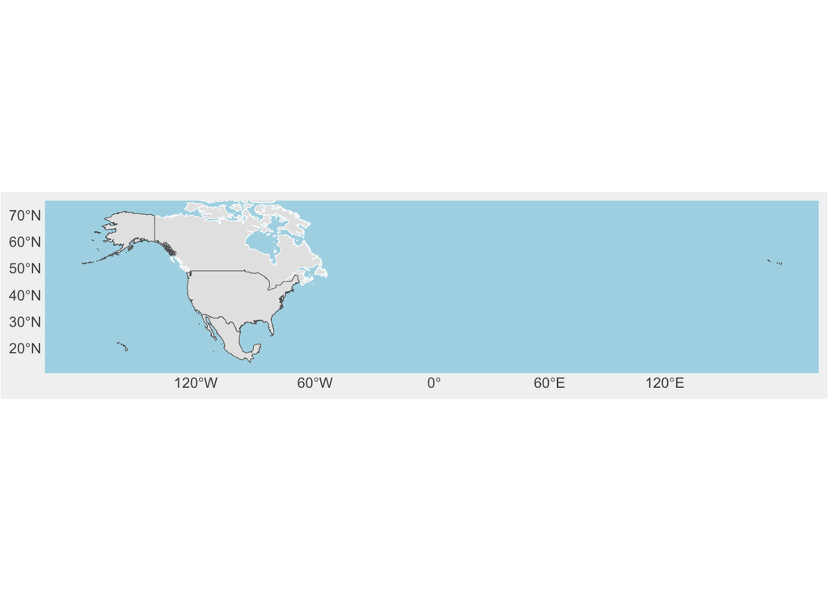

```r
ggplot() +
  geom_sf(data = neighbours, color = "white") +
  geom_sf(data = NApoly) +
  coord_sf(
    xlim = c(limsNA["xmin"], limsNA["xmax"]),
    ylim = c(limsNA["ymin"], limsNA["ymax"])
  ) +
  theme(
    plot.background = element_rect(fill = "#f1f2f3"),
    panel.background = element_rect(fill = "lightblue"),
    panel.grid = element_blank(),
    line = element_blank(),
    rect = element_blank()
  )
```

Hmmmm, that is somewhat ugly, let’s adjust the coordinates a bit the map and plot it again…

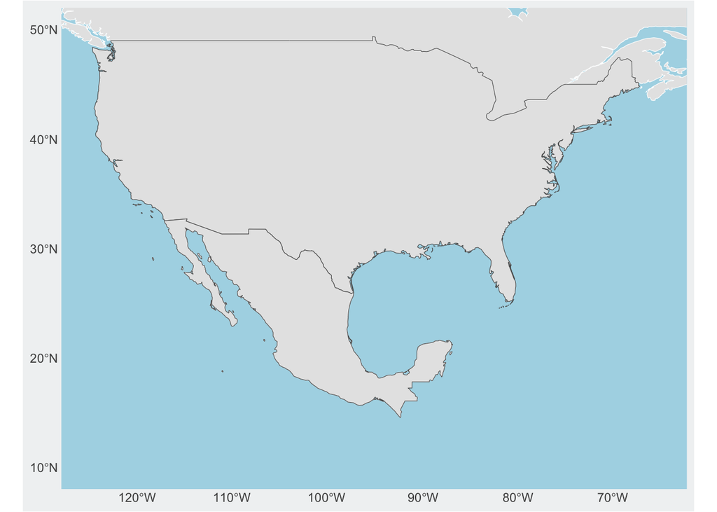

```r
ggplot() +
  geom_sf(data = neighbours, color = "white") +
  geom_sf(data = NApoly) +
  coord_sf(
     xlim = c(-125, -65),
    ylim = c(10, 50)
  ) +
  theme(
    plot.background = element_rect(fill = "#f1f2f3"),
    panel.background = element_rect(fill = "lightblue"),
    panel.grid = element_blank(),
    line = element_blank(),
    rect = element_blank()
  )
```

Much, much better!

Load species occurrences data points. We will use occurrences from Live oaks, that were obtained from iDigBio between 20 and 24 July 2018 by Jeannine Cavender-Bares. Notice that these occurrence data points were visually examined and any localities that were outside the known range of the species, or in unrealistic locations (e.g., water bodies, crop fields) were discarded.

```r
oaks_occ <- read_delim("Data/OCC/live.oaks.txt") %>%
  filter(Species != "Hybrid") # removing hybrid observations
oaks_occ %>%
  count(Species) # check how many species and how many observations per species
```

```
# A tibble: 7 × 2
  Species                n
  <chr>              <int>
1 Quercus_brandegei     35
2 Quercus_fusiformis    76
3 Quercus_geminata      51
4 Quercus_minima        38
5 Quercus_oleoides     292
6 Quercus_sagraena      40
7 Quercus_virginiana   134
```

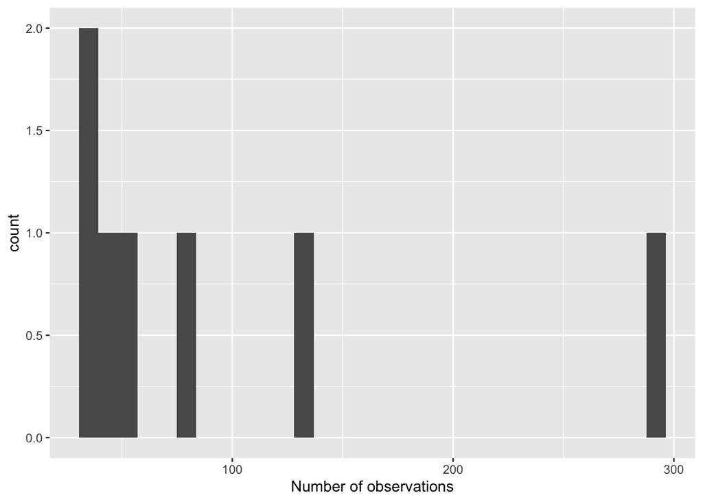

```r
# Visualize

oaks_occ %>%
  count(Species) %>%
  ggplot(aes(x = n)) +
  geom_histogram() +
  xlab("Number of observations")
```

Transform data.frame to spatial data.frame

```r
# to sf object, specifying variables with coordinates and projection
oaks_occ_sf <- st_as_sf(oaks_occ, coords = c("Longitude", "Latitude"), crs = 4326) %>%
  #group_by(species) %>%
  st_cast("MULTIPOINT") %>%
  group_by(Species) %>%
  summarize()
```

```
although coordinates are longitude/latitude, st_union assumes that they are
planar
```

```r
glimpse(oaks_occ_sf)
```

```
Rows: 7
Columns: 2
$ Species  <chr> "Quercus_brandegei", "Quercus_fusiformis", "Quercus_geminata"…
$ geometry <MULTIPOINT [°]> MULTIPOINT ((-110.1556 23.7..., MULTIPOINT ((-100.…
```

*What variables we have in the oaks_occ object?*

**Answer:** There are three variables, species, longitude and latitude.

*How many oak species are in the dataset?*

**Answer:** There are seven oak species.

```r
unique(oaks_occ$Species)
```

```
[1] "Quercus_virginiana" "Quercus_geminata"   "Quercus_minima"
[4] "Quercus_fusiformis" "Quercus_oleoides"   "Quercus_brandegei"
[7] "Quercus_sagraena"
```

What we did in the previous code was simply to transform a the data.frame object into a **spatial data.frame**. We can plot the results.

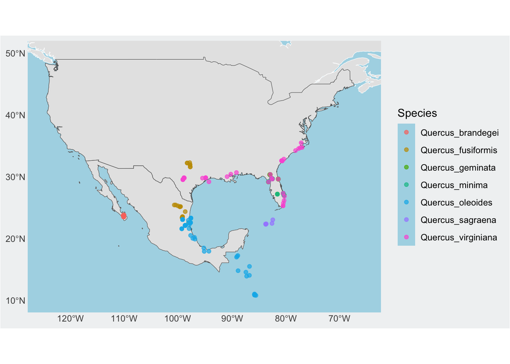

```r
ggplot() +
  geom_sf(data = neighbours, color = "white") +
  geom_sf(data = NApoly) +
  geom_sf(data = oaks_occ_sf, aes(color = Species), alpha = 0.7) +
  coord_sf(
     xlim = c(-125, -65),
    ylim = c(10, 50)
  ) +
  theme(
    plot.background = element_rect(fill = "#f1f2f3"),
    panel.background = element_rect(fill = "lightblue"),
    panel.grid = element_blank(),
    line = element_blank(),
    rect = element_blank()
  )
```

Nice!

## 2.1 Range maps from point data

In this section we will learn how to create “simple” range maps based on geometry (e.g. minimum convex polygons, etc.), without considering environmental variables (e.g., ENMs or SDMs). Note that these range maps are geographical abstractions of the species ranges. In other words, **a species range is the area where a particular species can be found during its lifetime. Species range includes areas where individuals or communities can migrate or hibernate**

We will explore two alternative, one based on simple **convex hull** and the other is the **smoothed convex hull**

### 2.1.1 Convex hull

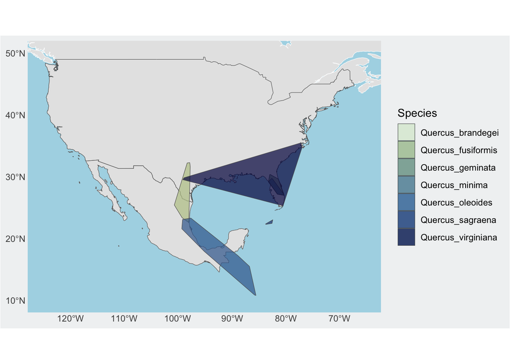

```r
# Observations to convex hull
oaks_CH <- st_convex_hull(oaks_occ_sf)

# plot hulls
ggplot() +
  geom_sf(data = neighbours, color = "white") +
  geom_sf(data = NApoly) +
  geom_sf(data = oaks_CH, aes(fill = Species), alpha = 0.7) +
  scale_fill_scico_d(palette = "davos", direction = -1, end = 0.9) +
  coord_sf(
    xlim = c(-125, -65),
    ylim = c(10, 50)
  ) +
  theme(
    plot.background = element_rect(fill = "#f1f2f3"),
    panel.background = element_rect(fill = "lightblue"),
    panel.grid = element_blank(),
    line = element_blank(),
    rect = element_blank()
  )
```

Now try the smoothed version.

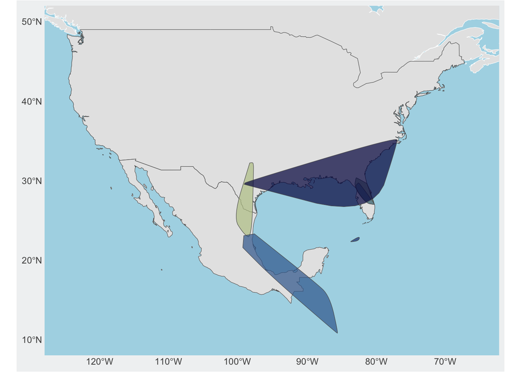

```r
# Smoothed convex hulls
oaks_SCH <- st_convex_hull(oaks_occ_sf) %>%
  smoothr::smooth()

# plot smoothed hulls
ggplot() +
  geom_sf(data = neighbours, color = "white") +
  geom_sf(data = NApoly) +
  geom_sf(data = oaks_SCH, aes(fill = Species), alpha = 0.7) +
  scale_fill_scico_d(palette = "davos", direction = -1, end = 0.9, guide = FALSE) +
  coord_sf(
    xlim = c(-125, -65),
    ylim = c(10, 50)
  ) +
  theme(
    plot.background = element_rect(fill = "#f1f2f3"),
    panel.background = element_rect(fill = "lightblue"),
    panel.grid = element_blank(),
    line = element_blank(),
    rect = element_blank()
  )
```

*Please explain the results. How do you feel about that?*

**Answer:** Out of the seven species, three have very large geographical ranges (*Q. virginiana*, *Q. oleoides*, and *Q. fusiformis*). The other four have small geographical ranges, of which *Q. brandegei* has the smallest range and is restricted to Baja California Sur, Mexico.

Until here we have explored how to plot, clean and build species geographical ranges using occurrences. Now we will use species geographical ranges of the largest continental endemic radiation (**Furnariides**) to explore the geographical gradients of species diversity.

# 3 Diversity gradients

## 3.1 Prepare data and mapping

The geographical ranges correspond to the Infraorder Furnariides (Aves). This data is available thorough [BirdLife International](http://datazone.birdlife.org/species/requestdis) and you can use any other group available on IUCN or BIEN (for plants in the Americas). In any case, you first need to download the polygons in shapefile format.

To load the Furnariides geographical ranges, we will use the function **st_read()** from the package **{sf}**. Please read the message printed on your console and try to understand the data.

```r
franges <- st_read("Data/Ranges/Furnarii_ranges_geo.shp")
```

Explore the imported data.

```r
class(franges)
```

```
[1] "sf"         "data.frame"
```

Now see all the data information.

```r
glimpse(franges)
```

```
Rows: 652
Columns: 16
$ SCINAME    <chr> "Acrobatornis fonsecai", "Acropternis orthonyx", "Anabacert…
$ Perimeter  <dbl> 3.889255, 38.861185, 47.712319, 114.669167, 87.950015, 40.7…
$ Area       <dbl> 1.908372e-01, 9.193185e+00, 4.477265e+01, 2.757285e+01, 1.7…
$ AreaKM2    <dbl> 1.908372e+03, 9.193185e+04, 4.477265e+05, 2.757285e+05, 1.7…
$ RD         <dbl> 17, 9, 17, 18, 18, 17, 17, 13, 16, 12, 12, 24, 18, 18, 17, …
$ DR         <dbl> 0.14478, 0.05713, 0.27500, 0.27008, 0.27944, 0.21302, 0.212…
$ BodyMass   <dbl> 13.70, 89.86, 19.20, 24.80, 27.80, 35.40, 39.00, 35.90, 41.…
$ DietInv    <dbl> 100, 80, 100, 100, 100, 100, 100, 100, 80, 100, 100, 100, 5…
$ DietFruit  <dbl> 0, 0, 0, 0, 0, 0, 0, 0, 0, 0, 0, 0, 0, 0, 0, 0, 0, 0, 0, 0,…
$ DietSeed   <dbl> 0, 0, 0, 0, 0, 0, 0, 0, 20, 0, 0, 0, 50, 0, 0, 0, 50, 0, 0,…
$ StratGroun <dbl> 0, 100, 20, 0, 0, 0, 10, 50, 50, 20, 10, 50, 80, 30, 70, 70…
$ Understory <dbl> 0, 0, 60, 0, 33, 0, 20, 50, 50, 80, 30, 50, 20, 70, 30, 30,…
$ Midhigh    <dbl> 40, 0, 20, 100, 33, 100, 70, 0, 0, 0, 30, 0, 0, 0, 0, 0, 0,…
$ Canopy     <dbl> 60, 0, 0, 0, 33, 0, 0, 0, 0, 0, 30, 0, 0, 0, 0, 0, 0, 0, 0,…
$ Ages       <dbl> 3.260995, 10.994344, 0.262984, 1.358152, 0.262984, 2.492379…
$ geometry   <MULTIPOLYGON [°]> MULTIPOLYGON (((-39.3059 -1..., MULTIPOLYGON (…
```

*What variables are present in the spatial polygon object?* and *How many species?*

**Answer:** There are 652 species in this spatial object. The variables included are: Perimeter, Area, AreaKM2, RD, DR, BodyMass, DietInv, DietFruit, DietSeed, StratGroun, Understory, Midhigh, Canopy, Ages.

```r
length(unique(franges$SCINAME))
```

```
[1] 652
```

```r
frangesVars <- names(franges)[2:15]

frangesVars
```

```
 [1] "Perimeter"  "Area"       "AreaKM2"    "RD"         "DR"
 [6] "BodyMass"   "DietInv"    "DietFruit"  "DietSeed"   "StratGroun"
[11] "Understory" "Midhigh"    "Canopy"     "Ages"
```

Let’s plot a couple of species.

```r
selSPP <- franges %>%
  filter(SCINAME == "Furnarius rufus" | SCINAME == "Anabazenops dorsalis")

# country subset
SApoly <- worldMap %>%
  filter(continent == "South America")
```

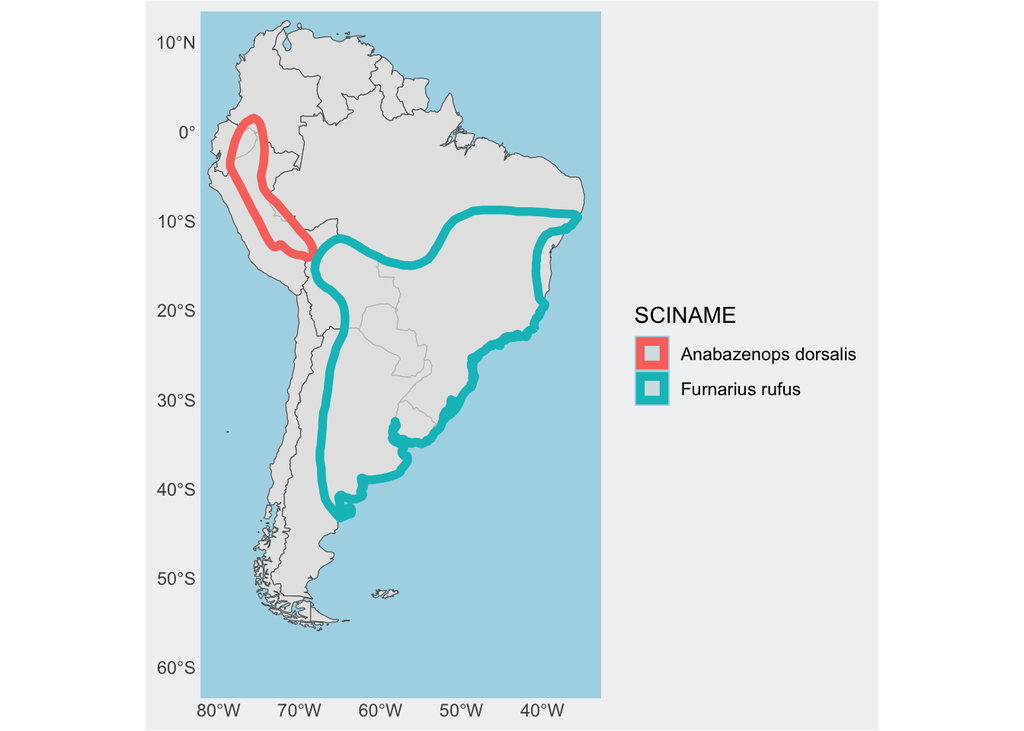

```r
# plot the selected ranges
ggplot() +
  geom_sf(data = SApoly) +
  geom_sf(data = selSPP, aes(color = SCINAME), alpha = 0.7, size = 2) +
  scale_fill_scico_d(palette = "davos", direction = -1,
                     end = 0.9, guide = FALSE) +
  coord_sf(
    xlim = c(-80, -35),
    ylim = c(10, -60)
  ) +
  theme(
    plot.background = element_rect(fill = "#f1f2f3"),
    panel.background = element_rect(fill = "lightblue"),
    panel.grid = element_blank(),
    line = element_blank(),
    rect = element_blank()
  )
```

*Explain the distribution for both species (i.e., Furnarius rufus [blue polygon] and Anabazenops dorsalis [red polygon])* *Are these species distributed in sympatry or allopatry? Explain the selected distribution pattern.*

**Answer:** *F. rufus* is widely distributed mostly in the lowlands of South America (Bolivia, Brazil, Paraguay, Uruguay and Argentina). *A. dorsalis* is has a more restricted distribution mostly in the Andes (Bolivia, Perú, Ecuador and Colombia). Despite these two species belong to the same lineaje (Family Furnariidae) they present an allopatric distribution

## 3.2 Raster of species richness

Species richness is the number of different species represented in an ecological community, landscape or region. Species richness is simply a count of species, and it does not take into account the abundances of the species or their relative abundance distributions.

Now, let’s create a map that represent the species richness of Furnariides.

First create an empty raster for the Neotropics using the extent of the Furnariides ranges under a spatial resolution of 1º long-lat or 111 km at the equator.

```r
# Create raster ro store richness values
neo_ras <- rast() # empty raster

ext(neo_ras) <- ext(franges) # Set the raster "extent"

res(neo_ras) <- 1 # Set the raster "resolution"

neo_ras # print the raster object in the console
```

```
class       : SpatRaster
size        : 85, 75, 1  (nrow, ncol, nlyr)
resolution  : 1, 1  (x, y)
extent      : -110.0817, -35.08174, -55.98222, 29.01778  (xmin, xmax, ymin, ymax)
coord. ref. : lon/lat WGS 84 (CRS84) (OGC:CRS84)
```

```r
values(neo_ras) <- 0 # assign O values to all pixels in the raster
```

Plot empty raster for the Neotropics

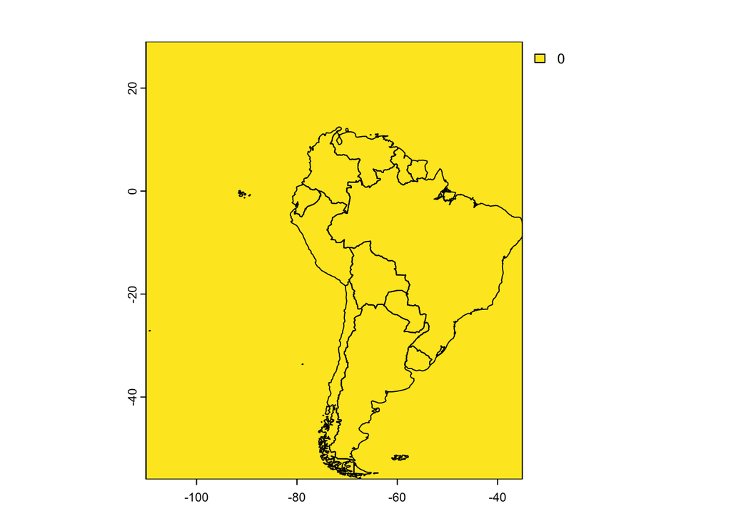

```r
# transform the sf object to a sp object
SApoly_sp <- as(SApoly, "Spatial")

# Plot empty raster
plot(neo_ras)

plot(SApoly_sp, add = TRUE) ## overlay SA countries to the SR map
```

Now using the empty raster we will **rasterize** the species identities in each cell or pixel. The resulting raster will be the species richness of Furnariides across the Neotropics.

```r
f_sr_raster <- terra::rasterizeGeom(x = vect(franges), # species geographical ranges
                         y = neo_ras, # empty raster
                         fun = "count" # count number of species per grid cell
                         )
# this process can take a while depending on your computer (~45 secs in Jesús's computer), please be patient.
```

Plot the resulting raster.

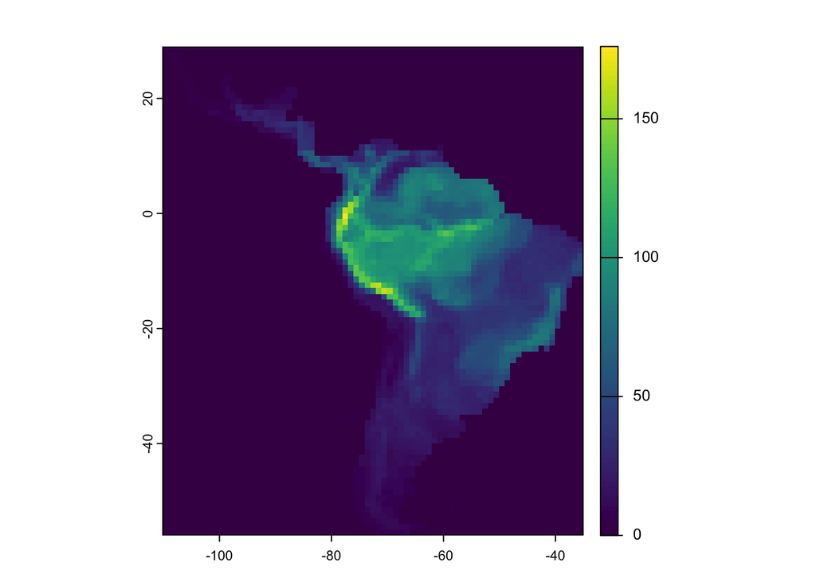

```r
plot(f_sr_raster)
```

Let’s try changing the colors using the package {viridis}

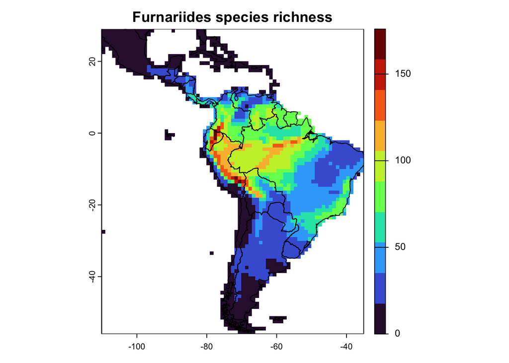

```r
# country subset
Apoly <- worldMap %>%
  filter(continent == "South America" | continent == "North America")

# transform the sf object to a sp object
Apoly_sp <- as(Apoly, "Spatial")

# Plot the information
plot(mask(f_sr_raster, Apoly), # raster of species richness
     col = viridis::turbo(10), # colors
     zlim = c(min(values(f_sr_raster),
                  max(values(f_sr_raster)))),
     main = "Furnariides species richness")

plot(Apoly_sp, add = TRUE) ## overlay SA countries to the SR map
```

Or we can try a more fancy way to plot the number of Furnariids’ species. To do that we can use the package {rasterVis} for plotting and the package {RColorBrewer} for selecting color combinations.

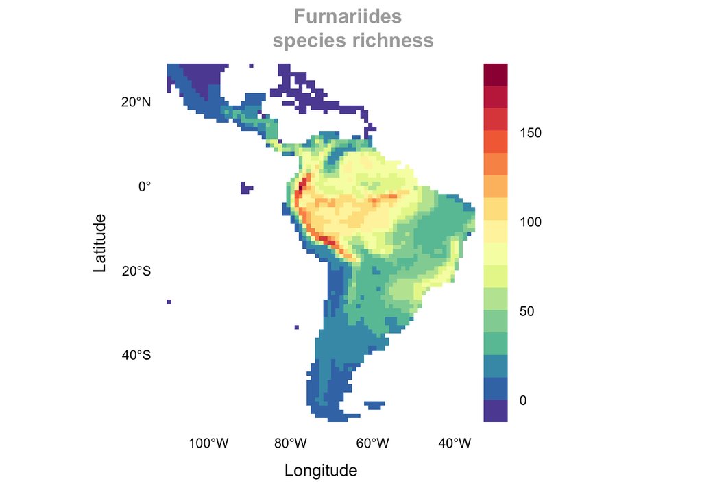

```r
library(rasterVis)
library(RColorBrewer)

# First set a theme
mapTheme <- rasterTheme(region = rev(brewer.pal(11, "Spectral")),
  layout.widths = list(right.padding = 10),
  axis.line = list(col = "transparent"),
  tick = list(col = 'transparent'))

## Now we can plot the raster
p_furna_SR <- levelplot(mask(f_sr_raster, Apoly),
  maxpixels = 1e10,
  margin = FALSE,
  main = list('Furnariides \n species richness', col = 'darkgray'),
  par.settings = mapTheme,
  scales = list(x = list(draw = TRUE),
                y = list(draw = TRUE)),
  zlim = c(0, 180))

p_furna_SR
```

*Awesome, right?. Now, please, describe the observed pattern!*

**Answer:** The map shows the classic latitudinal diversity gradient, with a higher accumulation of species close to the equator and a continued decline in the number of species as we approach the South Pole.

## 3.3 Scale dependency

Set the empty rasters.

```r
# 2º degrees
neo_ras_2dg <- rast()
# Set the raster "extent"
ext(neo_ras_2dg) <- ext(franges)
res(neo_ras_2dg) <- 2
neo_ras_2dg
```

```
class       : SpatRaster
size        : 43, 38, 1  (nrow, ncol, nlyr)
resolution  : 2, 2  (x, y)
extent      : -110.0817, -34.08174, -55.98222, 30.01778  (xmin, xmax, ymin, ymax)
coord. ref. : lon/lat WGS 84 (CRS84) (OGC:CRS84)
```

```r
values(neo_ras_2dg) <- 0

# 4º degrees
neo_ras_4dg <- rast()
# Set the raster "extent"
ext(neo_ras_4dg) <- ext(franges)
res(neo_ras_4dg) <- 4
neo_ras_4dg
```

```
class       : SpatRaster
size        : 21, 19, 1  (nrow, ncol, nlyr)
resolution  : 4, 4  (x, y)
extent      : -110.0817, -34.08174, -55.98222, 28.01778  (xmin, xmax, ymin, ymax)
coord. ref. : lon/lat WGS 84 (CRS84) (OGC:CRS84)
```

```r
values(neo_ras_4dg) <- 0

# 8º degrees
neo_ras_8dg <- rast()
# Set the raster "extent"
ext(neo_ras_8dg) <- ext(franges)
res(neo_ras_8dg) <- 8
neo_ras_8dg
```

```
class       : SpatRaster
size        : 11, 9, 1  (nrow, ncol, nlyr)
resolution  : 8, 8  (x, y)
extent      : -110.0817, -38.08174, -55.98222, 32.01778  (xmin, xmax, ymin, ymax)
coord. ref. : lon/lat WGS 84 (CRS84) (OGC:CRS84)
```

```r
values(neo_ras_8dg) <- 0
```

Now, rasterize the species richness to the desired pixel size.

```r
# Furnariides at 2º of long-lat
f_sr_2dg_raster <- terra::rasterizeGeom(x = vect(franges), # species geographical ranges
                         y = neo_ras_2dg, # empty raster
                         fun = "count" # count number of species per grid cell
                         )

# Furnariides at 4º of long-lat
f_sr_4dg_raster <- terra::rasterizeGeom(x = vect(franges), # species geographical ranges
                         y = neo_ras_4dg, # empty raster
                         fun = "count" # count number of species per grid cell
                         )

# Furnariides at 8º of long-lat
f_sr_8dg_raster <- terra::rasterizeGeom(x = vect(franges), # species geographical ranges
                         y = neo_ras_8dg, # empty raster
                         fun = "count" # count number of species per grid cell
                         )
```

Plot the four maps.

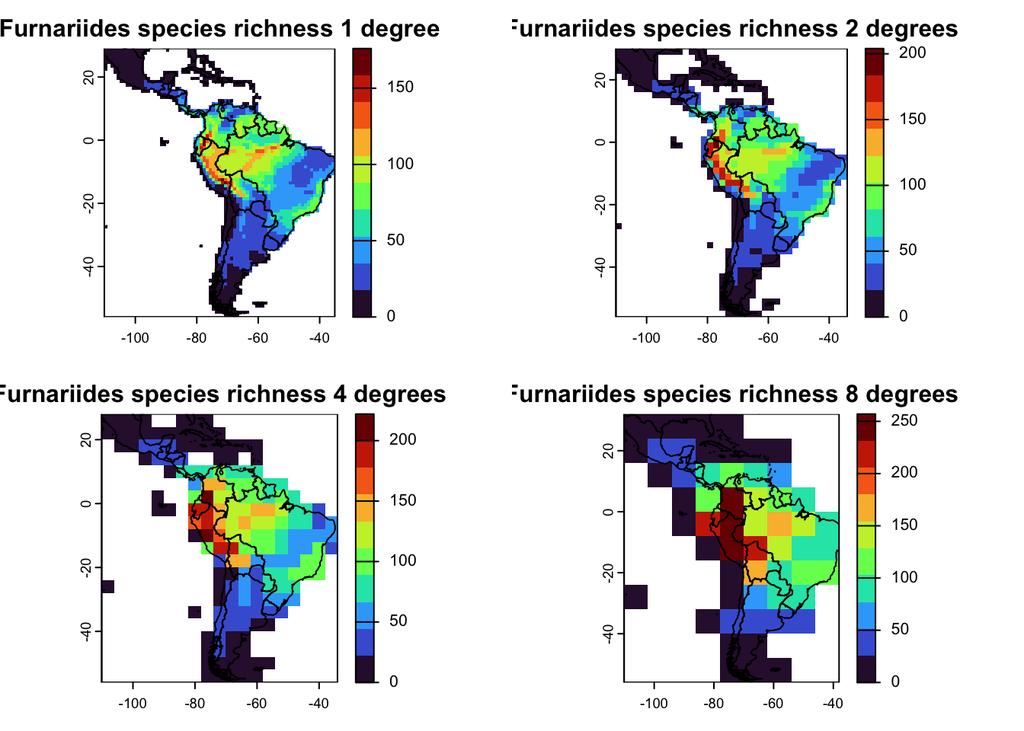

```r
par(mfrow = c(2, 2))

## Map at 1 degree grid cell
plot(mask(f_sr_raster, Apoly), # raster of species richness
     col = viridis::turbo(10), # colors
     zlim = c(min(values(f_sr_raster),
                  max(values(f_sr_raster)))),
     main = "Furnariides species richness 1 degree")

plot(Apoly_sp, add = TRUE)

## Map at 2 degrees grid cell
plot(mask(f_sr_2dg_raster, Apoly), # raster of species richness
     col = viridis::turbo(10), # colors
     zlim = c(min(values(f_sr_raster),
                  max(values(f_sr_raster)))),
     main = "Furnariides species richness 2 degrees")

plot(Apoly_sp, add = TRUE)

## Map at 4 degrees grid cell
plot(mask(f_sr_4dg_raster, Apoly), # raster of species richness
     col = viridis::turbo(10), # colors
     zlim = c(min(values(f_sr_raster),
                  max(values(f_sr_raster)))),
     main = "Furnariides species richness 4 degrees")

plot(Apoly_sp, add = TRUE)

## Map at 8 degrees grid cell
plot(mask(f_sr_8dg_raster, Apoly), # raster of species richness
     col = viridis::turbo(10), # colors
     zlim = c(min(values(f_sr_raster),
                  max(values(f_sr_raster)))),
     main = "Furnariides species richness 8 degrees")

plot(Apoly_sp, add = TRUE)
```

```r
#dev.off()
```

So, *is there an effect of spatial scale?*

**Answer:** Yes, with increasing the pixel size the pattern becomes diffuse and the detection of biogeographic patterns.

*Explain the differences between the four maps*

*How do you feel about that?*

**Answer:** The scale of analysis matters, and we should take care of it before making conclusions about the observed biodiversity patterns.

## 3.4 Correlative relationships

### 3.4.1 Species richness as a function of evolutionary history

Let’s try to rasterize another information from the polygon data set. We will use the information in the column **RD**, this data correspond to the numbers of nodes from the tips to the root of a phylogenetic tree or just **root distance**, thus, will use the RD to calculate the MRD metric **(mean root distance)** that measures the evolutionary derivedness of species within an assemblage (Kerr & Currie, 1999) and can be used to determine whether a local fauna is constituted primarily by early-diverged or by recently originated species (Hawkins et al., 2012; Pinto-Ledezma et al., 2017). In other words, high MRD values means that the community (i.e., grid-cell) is composed mostly by recently originated species, whereas low MRD values by early-diverged species.

```r
franges
```

```
Simple feature collection with 652 features and 15 fields
Geometry type: MULTIPOLYGON
Dimension:     XY
Bounding box:  xmin: -110.0817 ymin: -55.98222 xmax: -34.78897 ymax: 29.0965
Geodetic CRS:  WGS 84
First 10 features:
                      SCINAME  Perimeter         Area      AreaKM2 RD      DR
1       Acrobatornis fonsecai   3.889255 1.908372e-01 1.908372e+03 17 0.14478
2        Acropternis orthonyx  38.861185 9.193185e+00 9.193185e+04  9 0.05713
3      Anabacerthia amaurotis  47.712319 4.477265e+01 4.477265e+05 17 0.27500
4  Anabacerthia striaticollis 114.669167 2.757285e+01 2.757285e+05 18 0.27008
5  Anabacerthia variegaticeps  87.950015 1.797516e+01 1.797516e+05 18 0.27944
6        Anabazenops dorsalis  40.702820 5.437707e+01 5.437707e+05 17 0.21302
7          Anabazenops fuscus  51.742639 3.231765e+01 3.231765e+05 17 0.21293
8      Ancistrops strigilatus  72.320657 2.051860e+02 2.051860e+06 13 0.10415
```

[output cut: 24 more lines]

Rasterize the species’ **Root distance** to create a map of **Mean Root Distance**.

```r
f_MRD_raster <- terra::rasterize(vect(franges), # polygons
                          neo_ras, # empty raster
                          field = "RD", # Root distance
                          fun = mean # function mean
                          )
```

Plot the results

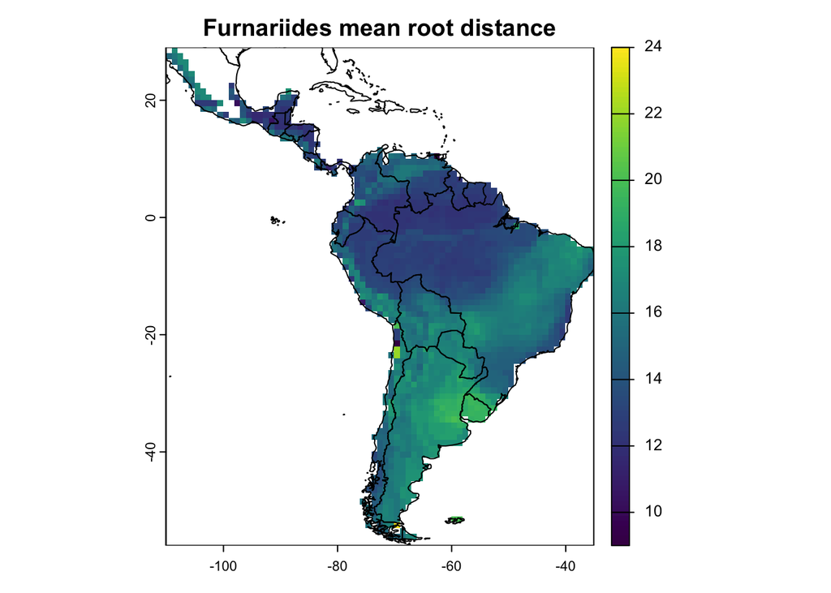

```r
plot(f_MRD_raster,
     main = 'Furnariides mean root distance')

plot(Apoly_sp, add = TRUE)
```

Let’s try changing the colors.

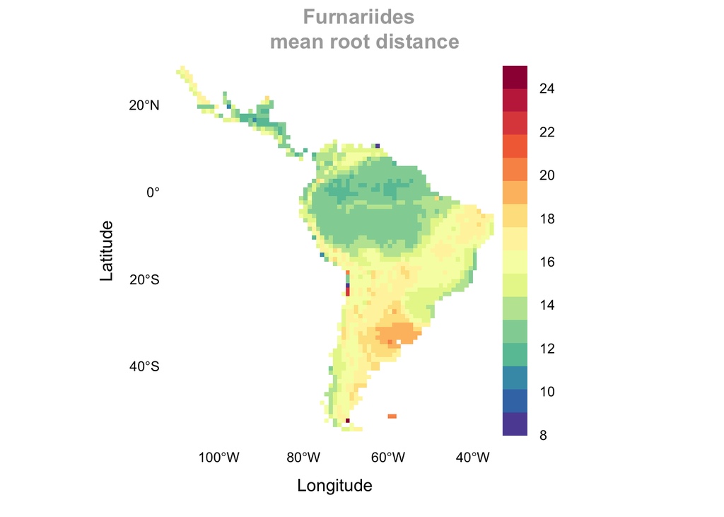

```r
## Now we can plot the raster
p_furna_MRD <- levelplot(f_MRD_raster,
  maxpixels = 1e10,
  margin = FALSE,
  main = list('Furnariides \n mean root distance', col = 'darkgray'),
  par.settings = mapTheme,
  scales = list(x = list(draw = TRUE),
                y = list(draw = TRUE)),
  zlim = c(0, 25))

p_furna_MRD
```

*Based on the description provided above, please describe the MRD pattern*

**Answer:** The map of mean root distance (MRD) shows an inverse pattern when compared with the patterns of species richness. Specifically, areas/pixels with a high number of species present low MRD, and areas/pixels with a low number of species have high MRD values. This might suggest that areas with low number of co-occurring species are mostly composed by recently-evolved species, conversely, areas with high number of species by species that diverged early in the evolutionary history of the clade.

Let’s plot both raster.

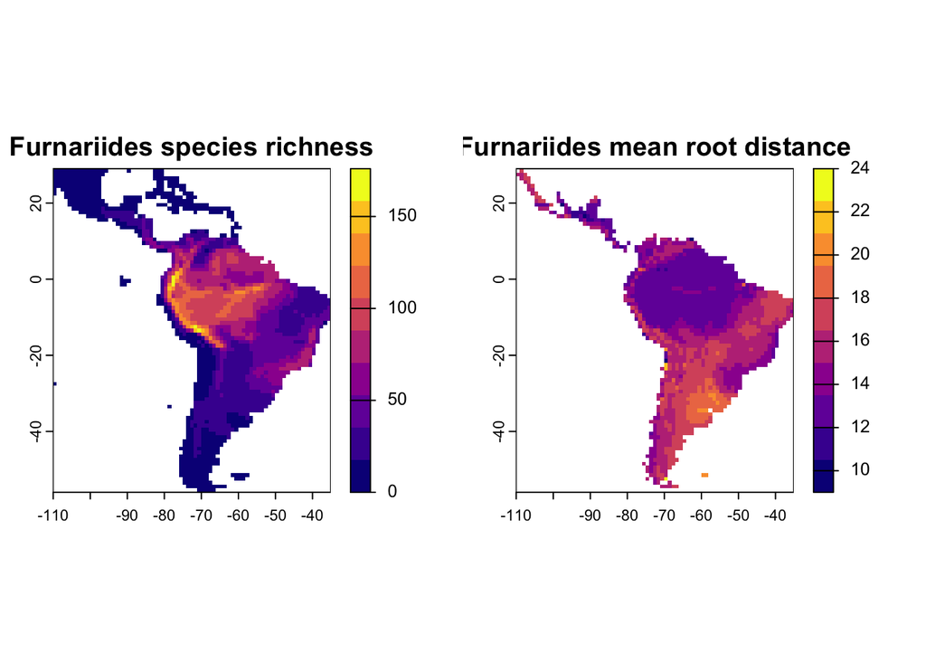

```r
par(mfrow = c(1, 2))

plot(mask(f_sr_raster, Apoly),
     col = viridis::plasma(10),
     main = "Furnariides species richness")

plot(mask(f_MRD_raster, Apoly),
     col = viridis::plasma(10),
     main = "Furnariides mean root distance")
```

```r
#dev.off()
```

Check if there is a relationship between the species richness and the evolutionary derivedness.

```r
cor.test(values(f_sr_raster), values(f_MRD_raster))
```

```
    Pearson's product-moment correlation

data:  values(f_sr_raster) and values(f_MRD_raster)
t = -32.945, df = 1644, p-value < 2.2e-16
alternative hypothesis: true correlation is not equal to 0
95 percent confidence interval:
 -0.6588512 -0.6005926
sample estimates:
       cor
-0.6306094
```

Or as in the previous lab, we can create a model that explain the association.

```r
obj <- lm(values(f_sr_raster) ~ values(f_MRD_raster))

summary(obj)
```

```
Call:
lm(formula = values(f_sr_raster) ~ values(f_MRD_raster))

Residuals:
     Min       1Q   Median       3Q      Max
-109.581  -13.659   -0.013   13.919  115.372

Coefficients:
                     Estimate Std. Error t value Pr(>|t|)
(Intercept)            209.46       4.83   43.37   <2e-16 ***
values(f_MRD_raster)   -10.54       0.32  -32.95   <2e-16 ***
---
Signif. codes:  0 '***' 0.001 '**' 0.01 '*' 0.05 '.' 0.1 ' ' 1

Residual standard error: 25.81 on 1644 degrees of freedom
  (4729 observations deleted due to missingness)
Multiple R-squared:  0.3977,    Adjusted R-squared:  0.3973
F-statistic:  1085 on 1 and 1644 DF,  p-value: < 2.2e-16
```

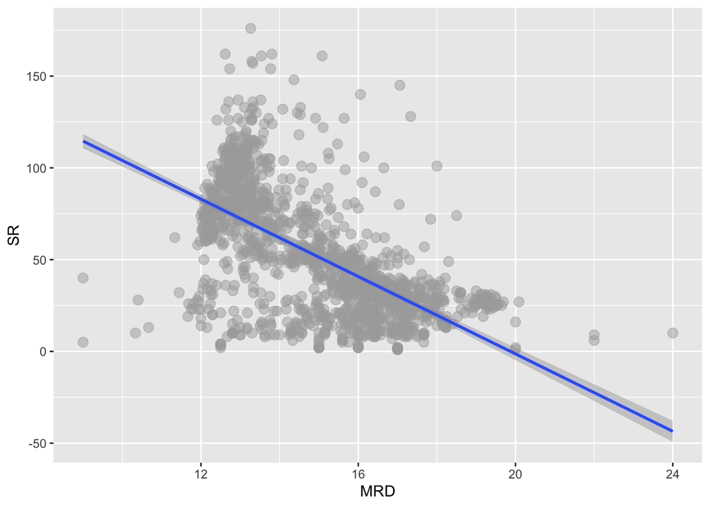

```r
# get pixel values from raster richness
data_sr <- as.data.frame(f_sr_raster, xy = TRUE)

# get pixel values from raster MRD
data_mrd <- as.data.frame(f_MRD_raster, xy = TRUE)

# Combine both datasets
data_sr_mrd <- left_join(data_sr, data_mrd, by = c("x", "y")) %>%
  rename(SR = count, MRD = RD) %>%
  drop_na(MRD)

# Plot the association
data_sr_mrd %>%
  ggplot(aes(x = MRD, y = SR)) +
  geom_point(color = "darkgray", size = 3, alpha = 0.5) +
  geom_smooth(method = "lm")
```

Hmmm. What happened in here? Please answer the next questions.

*From the mean root distance map, it is possible to explain the Furnariides diversity gradient? If so, please explain from an evolutionary perspective*.

**Answer:** Species-rich areas present low MRD values, and species-poor areas present high MRD values. MRD is a metric that measures deriveness, and high MRD means that assemblages are composed of recently evolved species. This can also be interpreted as these pixels/areas also present higher speciation rates. On the contrary, areas with low MRD will present low rates of speciation, and the higher species richness in these areas is a product of steady but low rates of speciation.

**TipSave the figures**

There are multiple options to save the figures. Jesús particularly like saving his figures in **PDF**. To save the figures in a pdf file, you can use the following code.

pdf(“association_MRD_SR.pdf”, height = 5, width = 7)

data_sr_mrd %>% ggplot(aes(x = MRD, y = SR)) + geom_point(color = “darkgray”) + geom_smooth(method = “lm”)

dev.off()

This lines will save your figure in your working directory.

### 3.4.2 Species richness as a function of environment

Load the environmental variables that correspond to bio1 (**Annual Mean Temperature**) and bio12 (**Annual Precipitation**). These data correspond to two variables out of 19 from WorldClim (http://www.worldclim.org/current). We will use these two variables just for educational purposes, rather to make a complete evaluation of the species-environmental relationships.

```r
# Annual Mean Temperature
bio1 <- rast("Data/BioClim/bio1.bil")
bio1 <- bio1/10

# Annual Precipitation
bio12 <- rast("Data/BioClim/bio12.bil")
bio12
```

```
class       : SpatRaster
size        : 900, 2160, 1  (nrow, ncol, nlyr)
resolution  : 0.1666667, 0.1666667  (x, y)
extent      : -180, 180, -60, 90  (xmin, xmax, ymin, ymax)
coord. ref. : lon/lat WGS 84 (EPSG:4326)
source      : bio12.bil
name        : bio12
min value   :     0
max value   :  9916
```

Plot the environmental variables

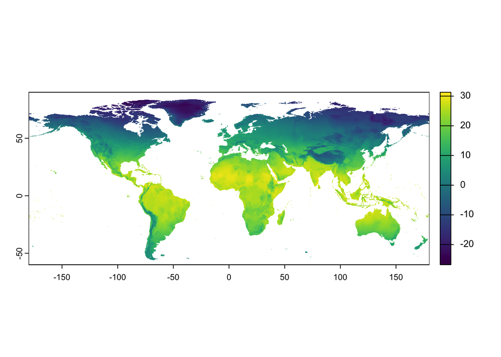

```r
plot(bio1)
```

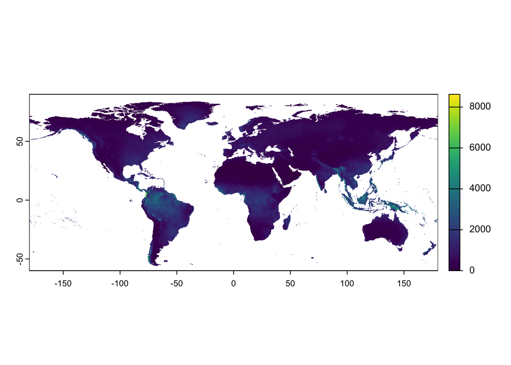

```r
plot(bio12)
```

Ok, the bio1 and bio12 layers are at global scale, so now will need to crop them to the extent of the Neotropics.

```r
bio1_neo <- crop(bio1, ext(franges))
bio12_neo <- crop(bio12, ext(franges))
```

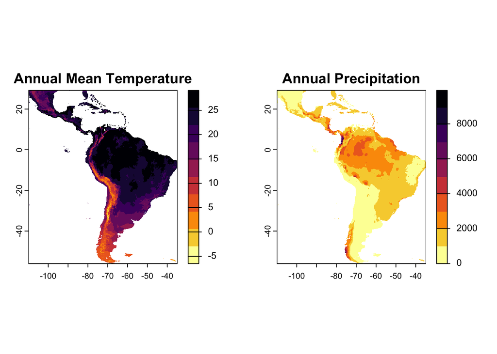

```r
par(mfrow = c(1, 2))

plot(bio1_neo, main = "Annual Mean Temperature",
     col = rev(viridis::inferno(10)))

plot(bio12_neo, main = "Annual Precipitation",
     col = rev(viridis::inferno(10)))
```

Much better!

Obtain the values from bio1, bio12, SR and MRD for each cell or pixel using the coordinates.

```r
# Get environmental data using coordinates from our maps
f_ras_bios <- extract(x = c(bio1_neo, bio12_neo), # environmental variables
                      y = data_sr_mrd[, c("x", "y")]) %>% # coordinates
  rename(MAT = bio1, MAP = bio12)

# Combine the information
fdata <- bind_cols(data_sr_mrd, f_ras_bios)

head(fdata)
```

```
          x        y SR MRD ID  MAT MAP
1 -108.5817 28.51778  1  17  1 15.4 720
2 -109.5817 27.51778  2  15  2 24.1 532
3 -108.5817 27.51778  2  16  3 19.6 799
4 -107.5817 27.51778  2  17  4 12.2 745
5 -108.5817 26.51778  2  15  5 24.4 624
6 -107.5817 26.51778  2  17  6 19.8 925
```

Now make a simple correlation between the Furnariides richness and bio1 and bio12.

Species richness correlated with Temperature

```r
cor.test(fdata$SR, fdata$MAT)
```

```
    Pearson's product-moment correlation

data:  fdata$SR and fdata$MAT
t = 23.101, df = 1644, p-value < 2.2e-16
alternative hypothesis: true correlation is not equal to 0
95 percent confidence interval:
 0.4576616 0.5306551
sample estimates:
      cor
0.4950313
```

Species richness correlated with Precipitation

```r
cor.test(fdata$SR, fdata$MAP)
```

```
    Pearson's product-moment correlation

data:  fdata$SR and fdata$MAP
t = 35.034, df = 1644, p-value < 2.2e-16
alternative hypothesis: true correlation is not equal to 0
95 percent confidence interval:
 0.6252291 0.6806113
sample estimates:
      cor
0.6537949
```

And also the linear model…

```r
lmbio1 <- lm(SR ~ MAT, data = fdata)

summary(lmbio1)
```

```
Call:
lm(formula = SR ~ MAT, data = fdata)

Residuals:
    Min      1Q  Median      3Q     Max
-64.532 -20.247  -4.611  17.341 136.721

Coefficients:
            Estimate Std. Error t value Pr(>|t|)
(Intercept)  -2.9588     2.4722  -1.197    0.232
MAT           2.5696     0.1112  23.101   <2e-16 ***
---
Signif. codes:  0 '***' 0.001 '**' 0.01 '*' 0.05 '.' 0.1 ' ' 1

Residual standard error: 28.89 on 1644 degrees of freedom
Multiple R-squared:  0.2451,    Adjusted R-squared:  0.2446
F-statistic: 533.6 on 1 and 1644 DF,  p-value: < 2.2e-16
```

```r
lmbio12 <- lm(SR ~ MAP, data = fdata)

summary(lmbio12)
```

```
Call:
lm(formula = SR ~ MAP, data = fdata)

Residuals:
     Min       1Q   Median       3Q      Max
-125.633  -13.056   -3.016   12.382  115.190

Coefficients:
             Estimate Std. Error t value Pr(>|t|)
(Intercept) 1.429e+01  1.236e+00   11.57   <2e-16 ***
MAP         2.471e-02  7.053e-04   35.03   <2e-16 ***
---
Signif. codes:  0 '***' 0.001 '**' 0.01 '*' 0.05 '.' 0.1 ' ' 1

Residual standard error: 25.16 on 1644 degrees of freedom
Multiple R-squared:  0.4274,    Adjusted R-squared:  0.4271
F-statistic:  1227 on 1 and 1644 DF,  p-value: < 2.2e-16
```

*Which environmental variable is more related with Furnariides richness?*

**Answer:** Both MAT and MAP are positively associated with the number of species. However, MAP shows a more steeper association than MAT. Also, MAP (R^2 = 0.43) explain more variance than MAT (R^2 = 0.24).

*Please explain the relationship from an ecological perspective*

**Answer:** The positive association between MAP and MAT with the number of species suggests that wetter and hotter areas contain more species. This might suggest that these areas present high local heterogeneity, allowing more species to coexist or to accumulate over time.

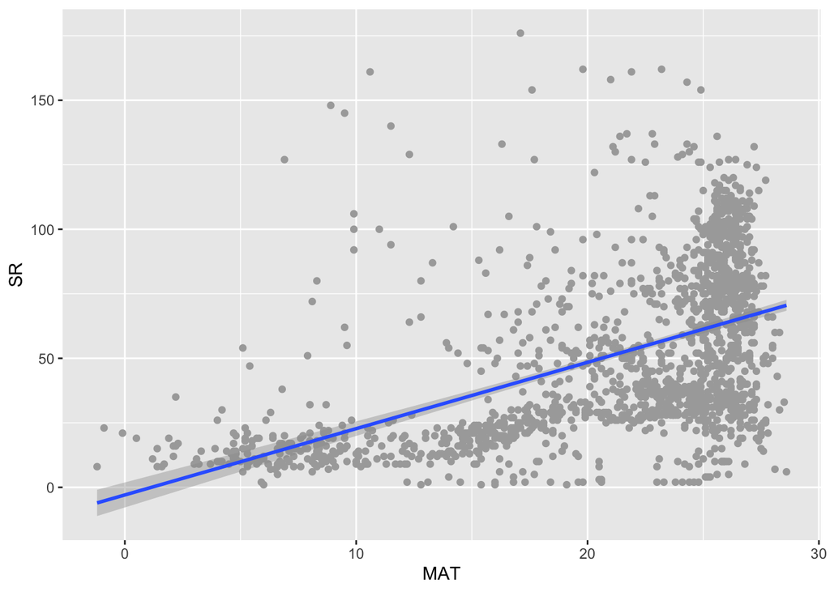

```r
fdata %>%
  ggplot(aes(x = MAT, y = SR)) +
  geom_point(color = "darkgray") +
  geom_smooth(method = "lm")
```

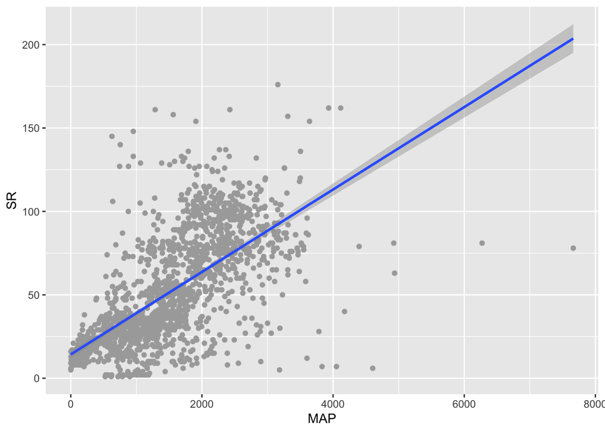

```r
fdata %>%
  ggplot(aes(x = MAP, y = SR)) +
  geom_point(color = "darkgray") +
  geom_smooth(method = "lm")
```

## 3.5 Considering spatial autocorrelation

This paragraph was extracted entirely from (F. Dormann et al., 2007): The analysis of spatial data is complicated by a phenomenon known as spatial autocorrelation. Spatial autocorrelation **(SAC)** occurs when the values of variables sampled at nearby locations are not independent from each other (Tobler, 1970). The causes of spatial autocorrelation are manifold, but three factors are particularly common: 1) biological processes such as speciation, extinction, dispersal or species interactions are distance‐related; 2) non‐linear relationships between environment and species are modelled erroneously as linear; 3) the statistical model fails to account for an important environmental determinant that in itself is spatially structured and thus causes spatial structuring in the response (Besag, 1974). Since they also lead to autocorrelated residuals, these are equally problematic. A fourth source of spatial autocorrelation relates to spatial resolution, because coarser grains lead to a spatial smoothing of data. In all of these cases, SAC may confound the analysis of species distribution data.

We know that a correlation is not a causation, so, to explore the relationship we need to build a model or fit a model. To explore this relationships we will first explore a simple Ordinary Least Square regression or OLS.

```r
fols <- lm(SR ~ MAT + MAP, data = fdata)

summary(fols)
```

```
Call:
lm(formula = SR ~ MAT + MAP, data = fdata)

Residuals:
     Min       1Q   Median       3Q      Max
-106.713  -13.998   -2.648   11.496  123.965

Coefficients:
             Estimate Std. Error t value Pr(>|t|)
(Intercept) 0.3665430  2.1168885   0.173    0.863
MAT         0.9307702  0.1159763   8.026 1.91e-15 ***
MAP         0.0208258  0.0008444  24.664  < 2e-16 ***
---
Signif. codes:  0 '***' 0.001 '**' 0.01 '*' 0.05 '.' 0.1 ' ' 1

Residual standard error: 24.69 on 1643 degrees of freedom
Multiple R-squared:  0.449, Adjusted R-squared:  0.4484
F-statistic: 669.6 on 2 and 1643 DF,  p-value: < 2.2e-16
```

Let’s complicate our model a little bit… Now let’s include the MRD values as covariable (Aka predictor).

```r
fols2 <- lm(SR ~ MAT + MAP + MRD, data = fdata)

summary(fols2)
```

```
Call:
lm(formula = SR ~ MAT + MAP + MRD, data = fdata)

Residuals:
    Min      1Q  Median      3Q     Max
-74.091 -10.068  -1.527  10.212 125.040

Coefficients:
              Estimate Std. Error t value Pr(>|t|)
(Intercept) 97.6603034  7.3781786  13.236  < 2e-16 ***
MAT          0.7196253  0.1109731   6.485 1.17e-10 ***
MAP          0.0133778  0.0009673  13.830  < 2e-16 ***
MRD         -5.4480900  0.3975883 -13.703  < 2e-16 ***
---
Signif. codes:  0 '***' 0.001 '**' 0.01 '*' 0.05 '.' 0.1 ' ' 1

Residual standard error: 23.39 on 1642 degrees of freedom
Multiple R-squared:  0.5056,    Adjusted R-squared:  0.5047
F-statistic: 559.7 on 3 and 1642 DF,  p-value: < 2.2e-16
```

*Can we compare the coefficients of this model?*

**Answer:** The answer might seems trivial but actually to make inferences using statistical models we first need to scale the predictors, so model coefficients are in the same scale.

```r
fdata_scaled <- fdata

fdata_scaled[, c(4, 6, 7)] <- apply(X = fdata_scaled[, c(4, 6, 7)], MARGIN = 2, FUN = arm::rescale)

head(fdata_scaled)
```

```
          x        y SR         MRD ID        MAT        MAP
1 -108.5817 28.51778  1 0.512396671  1 -0.4593292 -0.4520013
2 -109.5817 27.51778  2 0.009513822  2  0.2199452 -0.5588699
3 -108.5817 27.51778  2 0.260955247  3 -0.1314036 -0.4070938
4 -107.5817 27.51778  2 0.512396671  4 -0.7091772 -0.4377901
5 -108.5817 26.51778  2 0.009513822  5  0.2433685 -0.5065725
6 -107.5817 26.51778  2 0.512396671  6 -0.1157881 -0.3354692
```

Now, let’s us run our model with the rescale data.

```r
fols3 <- lm(SR ~ MAT + MAP + MRD, data = fdata_scaled)

summary(fols3)
```

```
Call:
lm(formula = SR ~ MAT + MAP + MRD, data = fdata_scaled)

Residuals:
    Min      1Q  Median      3Q     Max
-74.091 -10.068  -1.527  10.212 125.040

Coefficients:
            Estimate Std. Error t value Pr(>|t|)
(Intercept)  51.7303     0.5766  89.709  < 2e-16 ***
MAT           9.2168     1.4213   6.485 1.17e-10 ***
MAP          23.5339     1.7016  13.830  < 2e-16 ***
MRD         -21.6674     1.5812 -13.703  < 2e-16 ***
---
Signif. codes:  0 '***' 0.001 '**' 0.01 '*' 0.05 '.' 0.1 ' ' 1

Residual standard error: 23.39 on 1642 degrees of freedom
Multiple R-squared:  0.5056,    Adjusted R-squared:  0.5047
F-statistic: 559.7 on 3 and 1642 DF,  p-value: < 2.2e-16
```

*What is telling us these two OLS models?*

**Answer:** The first model, which includes MAT and MAP as predictors, suggests that species richness will increase as a function of increasing precipitation and temperature. This model explains 45% of the variation in species richness. It is important to highlight that despite the slopes being different from zero, the intercept does not, so this output should be considered exploratory.

The second model includes MRD as an additional covariable. By including MRD, the variation explained went up to 50%. So, including an evolutionary-informed covariable allowed us to explain better the variation in the number of species that co-occur in the Neotropics.

Now, explore the spatial autocorrelation of the Furnariides richness gradient. Spatial autocorrelation (it can also be temporal or phylogenetic) is a measure of similarity (**correlation**) between nearby observations. In other words, the spatial autocorrelation describe the degree two which observations (values) at spatial locations (whether they are points, areas, or raster cells), are similar to each other.

```r
autocor_SR <- ncf::correlog(fdata_scaled$x, # longitude
                            fdata_scaled$y, # latitude
                            z = fdata_scaled$SR, # species richness
                            na.rm = TRUE,
                            increment = 1,
                            resamp = 1)
```

Let’s use a correlogram to explore the spatial autocorrelation. Remember, spatial autocorrelation (it can also be temporal or phylogenetic) is a measure of similarity (**correlation**) between nearby observations. Thus, high values means high spatial autocorrelation.

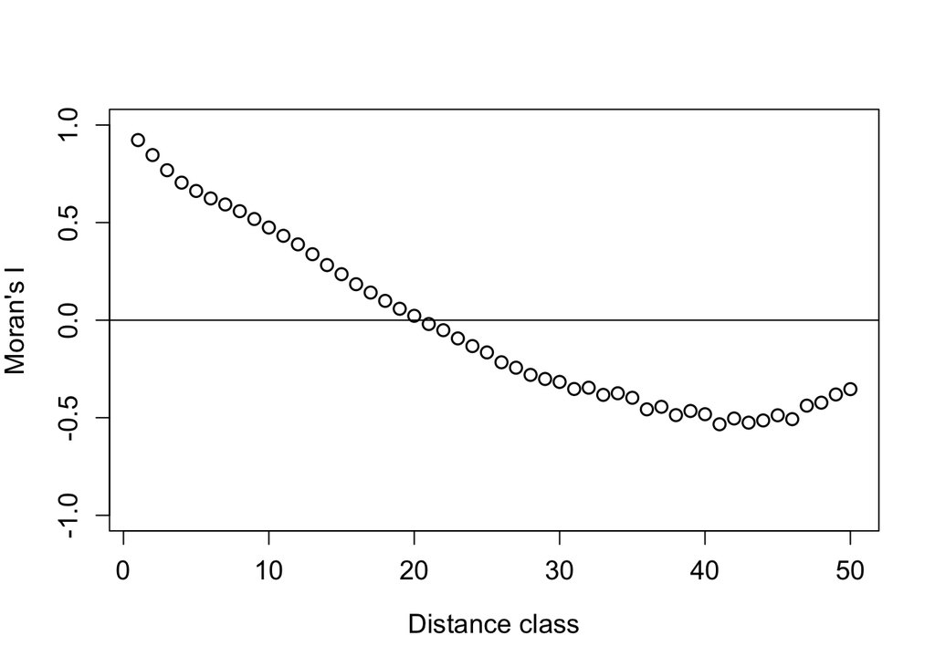

```r
plot(autocor_SR$correlation[1:50],
     type = "b", pch = 1, cex = 1.2, lwd = 1.5, ylim = c(-1, 1),
     xlab = "Distance class",
     ylab = "Moran's I",
     cex.lab = 1.2,
     cex.axis = 1.2)

abline(h = 0)
```

*Is there a spatial autocorrelation in the data? Please explain your answer*

**Answer:** Yes, we can see that close pixels are more similar in terms of the number of species than pixels that are farther apart. Notably, around the distance class 20, the positive spatial autocorrelation disappears.

What about the residuals? Let’s explore the spatial autocorrelation in the residuals.

```r
coords <- fdata_scaled[1:2]

coords <- as.matrix(coords)

head(coords)
```

```
             x        y
[1,] -108.5817 28.51778
[2,] -109.5817 27.51778
[3,] -108.5817 27.51778
[4,] -107.5817 27.51778
[5,] -108.5817 26.51778
[6,] -107.5817 26.51778
```

Build a neighborhood contiguity by distance. The distance used in this example is **1.5 degrees** but you can try with a large distance if you wish to explore more models.

```r
# neighborhood contiguity by distance
nb1.5 <- spdep::dnearneigh(coords, 0, 1.5)
```

Using the neighborhood contiguity build spatial weights for neighbor lists.

```r
nb1.5.w <- spdep::nb2listw(neighbours = nb1.5,
                           glist = NULL,
                           style = "W",
                           zero.policy = TRUE)
```

Extract the residuals from the OLS model

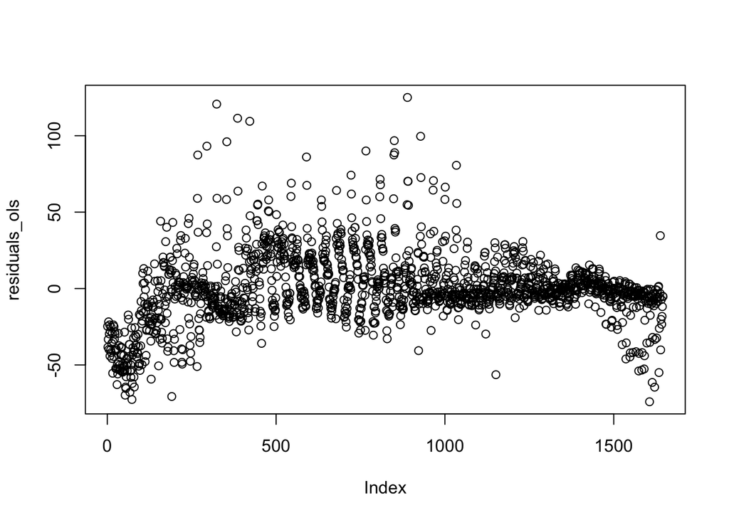

```r
residuals_ols <- residuals(fols3)

plot(residuals_ols)
```

Calculate a univariate spatial correlogram.

```r
autocor_ols_res <- ncf::correlog(x = fdata_scaled$x,
                            y = fdata_scaled$y,
                            z = residuals(fols3),
                            increment = 1,
                            resamp = 1)
```

Plot the autocorrelagram for the residuals

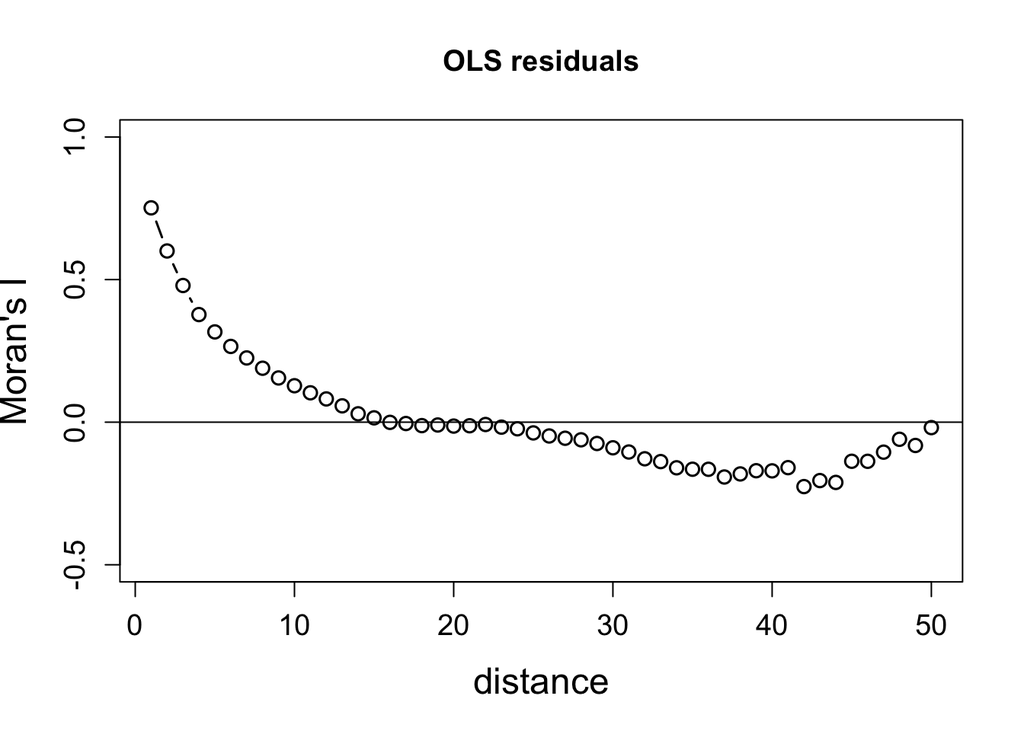

```r
plot(autocor_ols_res$correlation[1:50],
     type = "b", pch = 1, cex = 1.2, lwd = 1.5, ylim = c(-0.5, 1),
     xlab = "distance",
     ylab = "Moran's I",
     cex.lab = 1.5,
     cex.axis = 1.2)

abline(h = 0)

title(main = "OLS residuals", cex = 1.5)
```

*How many distance classes are necessary to eliminate the spatial autocorrelation in the residuals*

**Answer:** As in the case of species richness, the residuals also present high spatial autocorrelation at short distances, confirming that additional factors or processes are influencing the patterns we observe in nature. In other words, MAP, MAT, and MRD are insufficient to explain the variation in species richness.

Ohhh, seems that the residuals have a strong spatial autocorrelation, that is a problem because if we found autocorrelation in the residuals much of the explanation that we obtain can be biased. See explanation above.

Let’s inspect the two autocorrelograms.

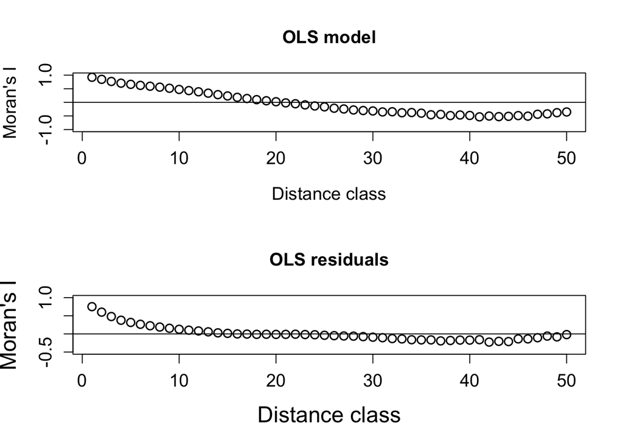

```r
par(mfrow = c(2, 1))

# Plot SR
plot(autocor_SR$correlation[1:50],
     type = "b", pch = 1, cex = 1.2,
     lwd = 1.5, ylim = c(-1, 1),
     xlab = "Distance class",
     ylab = "Moran's I",
     cex.lab = 1.2,
     cex.axis = 1.2)
abline(h = 0)
title(main = "OLS model", cex = 1.5)

# Plot residuals SR
plot(autocor_ols_res$correlation[1:50],
     type = "b", pch = 1, cex = 1.2,
     lwd = 1.5, ylim = c(-0.5, 1),
     xlab = "Distance class",
     ylab = "Moran's I",
     cex.lab = 1.5,
     cex.axis = 1.2)
abline(h = 0)
title(main = "OLS residuals", cex = 1.5)
```

Hmmm, seems that there is a strong spatial autocorrelation, thus any conclusion using the OLS model can be biased.

*How do you feel about that?*

**Answer:** Although simple linear models (OLS) can help us detect patterns to make inferences, we need to go at least one step ahead and explore the spatial structure of the data to better understand the factors and processes that generate the observed data.

To try to solve this important issue, we will use **spatial simultaneous autoregressive error model estimation (Aka SAR model)**, this kind of models account for spatial autocorrelation by adding an extra term (**autoregressive**) in the form of a spatial-weight matrix that specifies the neighborhood of each cell or pixel and the relative weight of each neighbor.

Let’s fit the SAR model.

```r
sar_nb1.5.w <- spatialreg::errorsarlm(fols3,
                                      listw = nb1.5.w,
                                      data = fdata_scaled,
                                      quiet = FALSE,
                                      zero.policy = TRUE,
                                      na.action = na.exclude)
```

```
Spatial autoregressive error model

Jacobian calculated using neighbourhood matrix eigenvalues
Computing eigenvalues ...

lambda: -0.236068  function: -7802.996  Jacobian: -6.146368  SSE: 1254089
lambda: 0.236068  function: -7213.873  Jacobian: -6.909469  SSE: 612417.1
lambda: 0.527864  function: -6783.873  Jacobian: -39.39779  SSE: 349135.3
lambda: 0.7082039  function: -6479.495  Jacobian: -80.34491  SSE: 229491.4
lambda: 0.8196601  function: -6267.65  Jacobian: -120.206  SSE: 169021.6
lambda: 0.8885438  function: -6137.484  Jacobian: -155.1728  SSE: 138293.6
lambda: 0.9311163  function: -6072.505  Jacobian: -184.1433  SSE: 123374.4
lambda: 0.9574275  function: -6046.676  Jacobian: -207.3018  SSE: 116245.1
lambda: 0.9736888  function: -6039.709  Jacobian: -225.3863  SSE: 112760.1
lambda: 0.9820408  function: -6040.039  Jacobian: -236.7272  SSE: 111261.5
lambda: 0.9768261  function: -6039.456  Jacobian: -229.4254  SSE: 112173.5
lambda: 0.977008  function: -6039.455  Jacobian: -229.667  SSE: 112140.3
lambda: 0.9771292  function: -6039.454  Jacobian: -229.8284  SSE: 112118.3
lambda: 0.9771207  function: -6039.454  Jacobian: -229.8171  SSE: 112119.9
lambda: 0.9771206  function: -6039.454  Jacobian: -229.8168  SSE: 112119.9
lambda: 0.9771206  function: -6039.454  Jacobian: -229.8169  SSE: 112119.9
lambda: 0.9771205  function: -6039.454  Jacobian: -229.8168  SSE: 112119.9
lambda: 0.9771206  function: -6039.454  Jacobian: -229.8168  SSE: 112119.9
```

```r
# this will take a while, ~10 seconds in Jesús's computer
```

```r
summary(sar_nb1.5.w)
```

```
Call:spatialreg::errorsarlm(formula = fols3, data = fdata_scaled,
    listw = nb1.5.w, na.action = na.exclude, quiet = FALSE, zero.policy = TRUE)

Residuals:
     Min       1Q   Median       3Q      Max
-45.6541  -2.6715  -0.4562   2.1783  52.8991

Type: error
Coefficients: (asymptotic standard errors)
            Estimate Std. Error z value  Pr(>|z|)
(Intercept)  42.7988     8.8949  4.8116 1.497e-06
MAT          -4.1816     1.2265 -3.4094  0.000651
MAP           3.2773     1.0822  3.0284  0.002458
MRD          -3.0236     1.0979 -2.7540  0.005888

Lambda: 0.97712, LR test value: 2966.3, p-value: < 2.22e-16
Asymptotic standard error: 0.0044266
    z-value: 220.74, p-value: < 2.22e-16
Wald statistic: 48724, p-value: < 2.22e-16

Log likelihood: -6039.454 for error model
ML residual variance (sigma squared): 68.117, (sigma: 8.2533)
Number of observations: 1646
Number of parameters estimated: 6
AIC: 12091, (AIC for lm: 15055)
```

Extract the residuals from SAR model

```r
residuals_sar_nb1.5.w <- residuals(sar_nb1.5.w)
```

Now estimate the spatial autocorrelation of the SAR model.

```r
autocor_sar_nb1.5.w <- ncf::correlog(x = fdata_scaled$x,
                                     y = fdata_scaled$y,
                                     z = residuals(sar_nb1.5.w),
                                     na.rm = TRUE,
                                     increment = 1,
                                     resamp = 1)
```

Plot the autocorrelogram under the SAR model.

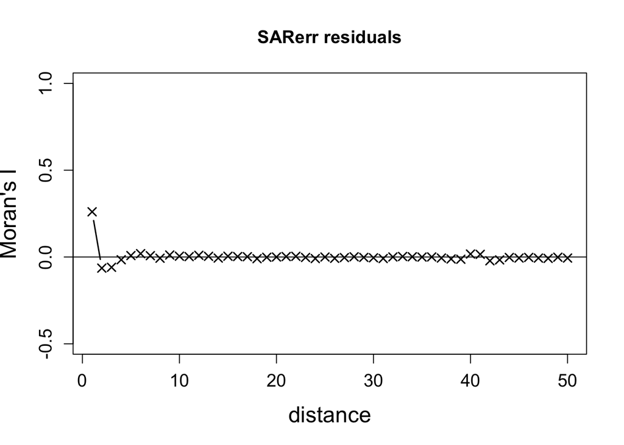

```r
plot(autocor_sar_nb1.5.w$correlation[1:50],
     type = "b", pch = 4, cex = 1.2,
     lwd = 1.5, ylim = c(-0.5, 1),
     xlab = "distance",
     ylab = "Moran's I",
     cex.lab = 1.5,
     cex.axis = 1.2)

abline(h = 0)

title(main = "SARerr residuals", cex = 1.5)
```

Ohhh, where is the autocorrelation in the residuals? Now compare the two autocorrelograms.

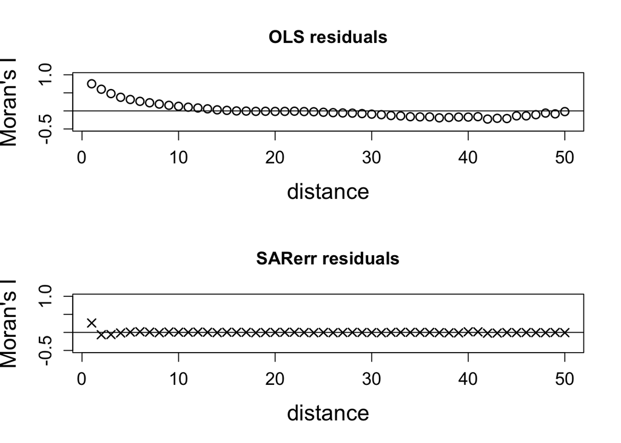

```r
par(mfrow = c(2, 1))

plot(autocor_ols_res$correlation[1:50],
     type = "b", pch = 1, cex = 1.2,
     lwd = 1.5, ylim = c(-0.5, 1),
     xlab = "distance",
     ylab = "Moran's I", cex.lab = 1.5,
     cex.axis = 1.2)
abline(h = 0)
title(main = "OLS residuals", cex = 1.5)

plot(autocor_sar_nb1.5.w$correlation[1:50],
     type = "b", pch = 4, cex = 1.2,
     lwd = 1.5, ylim = c(-0.5, 1),
     xlab = "distance",
     ylab = "Moran's I",
     cex.lab = 1.5,
     cex.axis = 1.2)
abline(h = 0)
title(main = "SARerr residuals", cex = 1.5)
```

Ok, now we know that the SAR model can solve the problem in the spatial autocorrelation in the residuals, let’s try to make some inferences.

```r
summary(sar_nb1.5.w)
```

```
Call:spatialreg::errorsarlm(formula = fols3, data = fdata_scaled,
    listw = nb1.5.w, na.action = na.exclude, quiet = FALSE, zero.policy = TRUE)

Residuals:
     Min       1Q   Median       3Q      Max
-45.6541  -2.6715  -0.4562   2.1783  52.8991

Type: error
Coefficients: (asymptotic standard errors)
            Estimate Std. Error z value  Pr(>|z|)
(Intercept)  42.7988     8.8949  4.8116 1.497e-06
MAT          -4.1816     1.2265 -3.4094  0.000651
MAP           3.2773     1.0822  3.0284  0.002458
MRD          -3.0236     1.0979 -2.7540  0.005888

Lambda: 0.97712, LR test value: 2966.3, p-value: < 2.22e-16
Asymptotic standard error: 0.0044266
    z-value: 220.74, p-value: < 2.22e-16
Wald statistic: 48724, p-value: < 2.22e-16

Log likelihood: -6039.454 for error model
ML residual variance (sigma squared): 68.117, (sigma: 8.2533)
Number of observations: 1646
Number of parameters estimated: 6
AIC: 12091, (AIC for lm: 15055)
```

```r
summary(fols3)
```

```
Call:
lm(formula = SR ~ MAT + MAP + MRD, data = fdata_scaled)

Residuals:
    Min      1Q  Median      3Q     Max
-74.091 -10.068  -1.527  10.212 125.040

Coefficients:
            Estimate Std. Error t value Pr(>|t|)
(Intercept)  51.7303     0.5766  89.709  < 2e-16 ***
MAT           9.2168     1.4213   6.485 1.17e-10 ***
MAP          23.5339     1.7016  13.830  < 2e-16 ***
MRD         -21.6674     1.5812 -13.703  < 2e-16 ***
---
Signif. codes:  0 '***' 0.001 '**' 0.01 '*' 0.05 '.' 0.1 ' ' 1

Residual standard error: 23.39 on 1642 degrees of freedom
Multiple R-squared:  0.5056,    Adjusted R-squared:  0.5047
F-statistic: 559.7 on 3 and 1642 DF,  p-value: < 2.2e-16
```

*By looking to the summary of the SAR and OLS models, explain the differences in the coefficients between both models.*

**Answer:** The first difference is that the coefficients (intercepts and slopes) changed in strength and direction. More specifically, the covariable MAT that was positive now for the OLS model, under the SAR model is negative. The effect of MAP and MRD also decreased.

Let’s compare the slopes for both models in a similar way we did when we compared OLS versus PGLS. Let’s start with mean annual temperature.

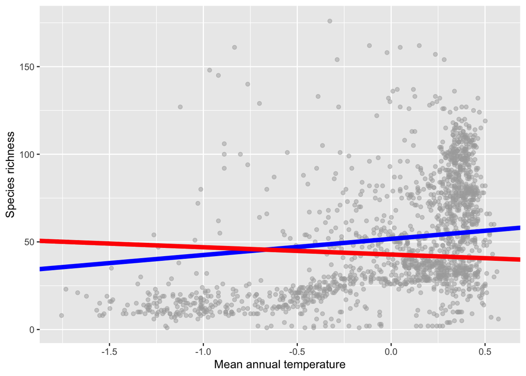

```r
fdata_scaled %>%
  ggplot(aes(x = MAT, y = SR)) +
  geom_point(alpha = 0.5, color = "darkgray") +
  labs(x = "Mean annual temperature",
       y = "Species richness") +
  geom_abline(intercept = coef(fols3)[1], # coefficient OLS
              slope = coef(fols3)[2],
              color = "blue",
              linewidth = 2) +
  geom_abline(intercept = coef(sar_nb1.5.w)[2], # coefficients SAR
              slope = coef(sar_nb1.5.w)[3],
              color = "red",
              linewidth = 2)
```

What about precipitation.

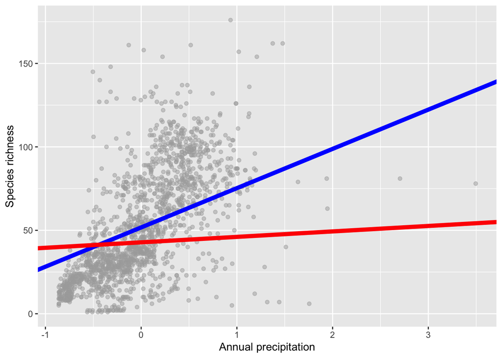

```r
fdata_scaled %>%
  ggplot(aes(x = MAP, y = SR)) +
  geom_point(alpha = 0.5, color = "darkgray") +
  labs(x = "Annual precipitation",
       y = "Species richness") +
  geom_abline(intercept = coef(fols3)[1], # coefficient OLS
              slope = coef(fols3)[3],
              color = "blue",
              linewidth = 2) +
  geom_abline(intercept = coef(sar_nb1.5.w)[2], # coefficients SAR
              slope = coef(sar_nb1.5.w)[4],
              color = "red",
              linewidth = 2)
```

And finally mean root distance

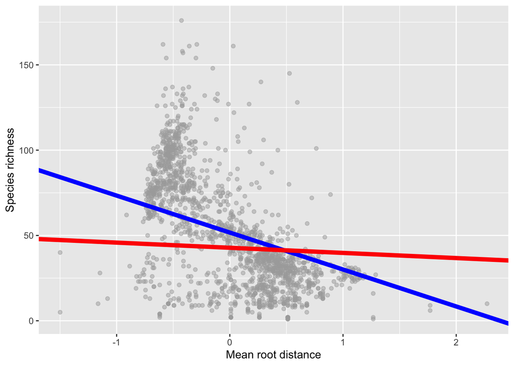

```r
fdata_scaled %>%
  ggplot(aes(x = MRD, y = SR)) +
  geom_point(alpha = 0.5, color = "darkgray") +
  labs(x = "Mean root distance",
       y = "Species richness") +
  geom_abline(intercept = coef(fols3)[1], # coefficient OLS
              slope = coef(fols3)[4],
              color = "blue",
              linewidth = 2) +
  geom_abline(intercept = coef(sar_nb1.5.w)[2], # coefficients SAR
              slope = coef(sar_nb1.5.w)[5],
              color = "red",
              linewidth = 2)
```

By inspecting the figures, we can see that sometimes, our conclusions about the factors influencing the patterns of biodiversity can change depending on how the data is analyzed.

The last exercise of this tutorial is to compare the prediction of both models. To calculate a R2 to the SAR model, we will use the function **SARr2()** from Jesús’s GitHub.

```r
source("https://raw.githubusercontent.com/jesusNPL/BetaDivNA/master/SARr2.R")
```

Calculate SAR R2

```r
SARr2(Lfull = sar_nb1.5.w$LL[[1]], # log likelihood of the model that includes the spatial weights
      Lnull = sar_nb1.5.w$logLik_lm.model[[1]], # log likelihood null model
      N = nrow(fdata) # number of observation
      )
```

```
[1] 0.8350546
```

Comparing the two models (OLS and SAR), please answer the following questions:

*1. Which model have the best explanation?*

**Answer:** The SAR model that includes the spatial structure of the data explain 84% of the variation in species richness. In contrast the OLS model only 50%.

*2. What can we conclude from these results?*

**Answer:** Although the covariables used in both models (SAR and OLS) help us to explain the variation in species richness, we can confirm that additional factors masked in the spatial structure of the data explain a high amount of variation.

*3. Do the slopes (betas) change from the OLS to the SAR? What about the R2?*

**Answer:** Yes, the coefficients and the R^2 changed drastically by taking into account the spatial structure of the data.

*4. How do you feel about that?*

**Answer:** Although simple models are useful for data exploration, if our ultimate goal is to make inferences about the processes that generate the data, then models that account for the structure of the data are necessary.

# 4 The challenge

Until now, we have analyzed several metrics based on phylogenies using the family Furnariidae. But, in order to better understand how our perception may (or may not) change when analyzing other clades and to gain more experience using R, the challenge for this lab is:

1. First option – repeat the process for the entire lineage but instead of mapping Mean root distance, you can map other variables within the dataset, e.g., body mass, age, range size, and answer the questions.
2. Second option – repeat the process but using a subclade within the Infraorder Furnariides. Remember, the Infraorder Furnariides is composed of six families (“Conopophagidae”, “Dendrocolaptidae” “Formicariidae”, “Furnariidae”, “Rhinocryptidae”, “Thamnophilidae”), you just need to select a family within Furnariides and explain the differences (if any) with the results found today.

The end! for now…

## References

Besag, J. (1974). Spatial interaction and the statistical analysis of lattice systems. *Journal of the Royal Statistical Society: Series B (Methodological)*, *36*(2), 192–225. https://doi.org/10.1111/j.2517-6161.1974.tb00999.x

Brown, J. H. (2014). Why are there so many species in the tropics? *Journal of Biogeography*, *41*(1), 8–22. https://doi.org/10.1111/jbi.12228

Currie, D. J., Mittelbach, G. G., Cornell, H. V., Field, R., Guegan, J.-F., Hawkins, B. A., Kaufman, D. M., Kerr, J. T., Oberdorff, T., O’Brien, E., & Turner, J. R. G. (2004). Predictions and tests of climate-based hypotheses of broad-scale variation in taxonomic richness. *Ecology Letters*, *7*(12), 1121–1134. https://doi.org/10.1111/j.1461-0248.2004.00671.x

F. Dormann, C., M. McPherson, J., B. Araújo, M., Bivand, R., Bolliger, J., Carl, G., G. Davies, R., Hirzel, A., Jetz, W., Daniel Kissling, W., Kühn, I., Ohlemüller, R., R. Peres-Neto, P., Reineking, B., Schröder, B., M. Schurr, F., & Wilson, R. (2007). Methods to account for spatial autocorrelation in the analysis of species distributional data: A review. *Ecography*, *30*(5), 609–628. https://doi.org/10.1111/j.2007.0906-7590.05171.x

Fine, P. V. A. (2015). Ecological and evolutionary drivers of geographic variation in species diversity. *Annual Review of Ecology, Evolution, and Systematics*, *46*(1), 369–392. https://doi.org/10.1146/annurev-ecolsys-112414-054102

Hawkins, B. A. (2001). Ecology’s oldest pattern? *Trends in Ecology & Evolution*, *16*(8), 470. https://doi.org/10.1016/S0169-5347(01)02197-8

Hawkins, B. A., & Felizola Diniz-Filho, J. A. (2004). “Latitude” and geographic patterns in species richness. *Ecography*, *27*(2), 268–272. https://doi.org/10.1111/j.0906-7590.2004.03883.x

Hawkins, B. A., Field, R., Cornell, H. V., Currie, D. J., Guégan, J.-F., Kaufman, D. M., Kerr, J. T., Mittelbach, G. G., Oberdorff, T., O’Brien, E. M., Porter, E. E., & Turner, J. R. G. (2003). ENERGY, WATER, AND BROAD-SCALE GEOGRAPHIC PATTERNS OF SPECIES RICHNESS. *Ecology*, *84*(12), 3105–3117. https://doi.org/10.1890/03-8006

Hawkins, B. A., McCain, C. M., Davies, T. J., Buckley, L. B., Anacker, B. L., Cornell, H. V., Damschen, E. I., Grytnes, J.-A., Harrison, S., Holt, R. D., Kraft, N. J. B., & Stephens, P. R. (2012). Different evolutionary histories underlie congruent species richness gradients of birds and mammals: Bird and mammal richness gradients. *Journal of Biogeography*, *39*(5), 825–841. https://doi.org/10.1111/j.1365-2699.2011.02655.x

Kerr, J. T., & Currie, D. J. (1999). The relative importance of evolutionary and environmental controls on broad-scale patterns of species richness in north america. *Écoscience*, *6*(3), 329–337. https://doi.org/10.1080/11956860.1999.11682546

O’Brien, E. M. (2006). Biological relativity to water?energy dynamics. *Journal of Biogeography*, *33*(11), 1868–1888. https://doi.org/10.1111/j.1365-2699.2006.01534.x

Pianka, E. R. (1966). Latitudinal gradients in species diversity: A review of concepts. *The American Naturalist*, *100*(910), 33–46. https://doi.org/10.1086/282398

Pinto-Ledezma, J. N., Simon, L. M., Diniz-Filho, J. A. F., & Villalobos, F. (2017). The geographical diversification of furnariides: The role of forest versus open habitats in driving species richness gradients. *Journal of Biogeography*, *44*(8), 1683–1693. https://doi.org/10.1111/jbi.12939

Ricklefs, R. E. (2004). A comprehensive framework for global patterns in biodiversity. *Ecology Letters*, *7*(1), 1–15. https://doi.org/10.1046/j.1461-0248.2003.00554.x

Rohde, K. (1992). Latitudinal gradients in species diversity: The search for the primary cause. *Oikos*, *65*(3), 514. https://doi.org/10.2307/3545569

Simpson, G. G. (1964). Species density of north american recent mammals. *Systematic Biology*, *13*(1), 57–73. https://doi.org/10.2307/sysbio/13.1-4.57

Tobler, W. R. (1970). A computer movie simulating urban growth in the detroit region. *Economic Geography*, *46*, 234. https://doi.org/10.2307/143141